# Figurative Portrait with Truchet Tiles

Load packages:

```r
library(ggplot2)
#library(igraph)
library(imager)
library(dplyr)
library(lwgeom)
library(MexBrewer)
library(purrr)
library(sf)
library(truchet)
```

## Create a figurative mosaic

Read the image using `imager::load.image()`:

```r
jn <- load.image("jay-en.jpg")
```

Image info:

```r
jn
```

```
Image. Width: 320 pix Height: 320 pix Depth: 1 Colour channels: 3
```

This is the image:

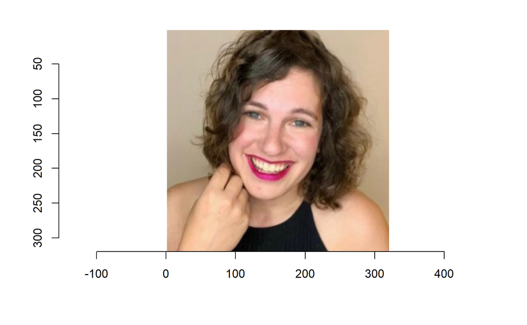

```r
plot(jn)
```

Resize image:

```r
jn_rs <- imresize(jn, scale = 8/10, interpolation = 6)
```

```r
color_df <- jn_rs %>%
  as.data.frame(wide="c") %>%
  # Reverse the y axis
  mutate(y = -(y - max(y)),
         hex_color = rgb(c.1,
                         c.2,
                         c.3))
```

Create data frame for the mosaic:

```r
# This will use a smaller subset of points to create the mosaic, which will then be rescaled
s <- 10

xlim <- c(min(df$x)/s - 4, max(df$x)/s + 4)
ylim <- c(min(df$y)/s - 4, max(df$y)/s + 4)

# Create a data frame with the spots for tiles
m_1 <- expand.grid(x = seq(xlim[1], xlim[2], 1),
                   y = seq(ylim[1], ylim[2], 1)) %>%
  mutate(tiles = sample(c("dl", "dr"), n(), replace = TRUE),
         scale_p = 1)
```

Create mosaic using the designed container:

```r
m_1 <- st_truchet_ms(df = m_1) %>%
  st_truchet_dissolve()
```

Dissolve and buffer:

```r
m_2 <- m_1 %>%
  st_buffer(dist = -0.1) %>%
  mutate(color = color + 2)

m_2 <- m_2[!st_is_empty(m_2), , drop = FALSE]

m_3 <- m_2 %>%
  st_truchet_dissolve() %>%
  st_buffer(dist = -0.1) %>%
  mutate(color = color + 2)

m_3 <- m_3[!st_is_empty(m_3), , drop = FALSE]
```

```r
m_1_lines <- m_1 %>%
  st_cast(to = "MULTILINESTRING")
m_2_lines <- m_2 %>%
  st_cast(to = "MULTILINESTRING")
m_3_lines <- m_3 %>%
  st_cast(to = "MULTILINESTRING")
```

Now this needs to be scaled to the size of the image. First get the union of the geometries:

```r
m_1_union <- st_union(m_1)
m_2_union <- st_union(m_2)
m_2_union <- st_union(m_3)
```

Then scale and recenter:

```r
m_1_union <- (m_1_lines * s) %>%
  st_sf()
m_2_union <- (m_2_lines * s) %>%
  st_sf()
m_3_union <- (m_3_lines * s) %>%
  st_sf()
```

Put it all together:

```r
mosaic <- rbind(m_1_union %>%
                  mutate(m = "1"),
                m_2_union %>%
                  mutate(m = "2"),
                m_3_union %>%
                  mutate(m = "3"))
```

Create a blade:

```r
bbox <- st_bbox(mosaic) %>%
  round()

blade <- data.frame(x_start = c(bbox$xmin:bbox$xmax,
                                rep(bbox$ymin,
                                    length(bbox$ymin:bbox$ymax))),
                    x_end = c(bbox$xmin:bbox$xmax,
                              rep(bbox$xmax,
                                  length(bbox$ymin:bbox$ymax))),
                    y_start = c(rep(bbox$ymin,
                                    length(bbox$xmin:bbox$xmax)),
                                bbox$ymin:bbox$ymax),
                    y_end = c(rep(bbox$ymax,
                                  length(bbox$xmin:bbox$xmax)),
                              bbox$ymin:bbox$ymax))

# Shift the blade a small amount to avoid perfect overlap with underlying grid
blade <- blade %>%
  mutate(across(everything(),
                ~ .x + 0.28))

blade <- pmap(blade, function(x_start, x_end, y_start, y_end){
  st_linestring(
    matrix(
      c(
        x_start,
        y_start,
        x_end,
        y_end),
      ncol = 2,byrow = TRUE)
  )
}) %>%
  st_as_sfc()
```

Use the blade to split the lines (this is one of the computational bottlenecks - this takes time):

```r
mosaic_lines <- mosaic %>%
  st_split(blade)
```

Extract the geometries:

```r
mosaic_lines <- mosaic_lines %>%
  st_collection_extract(type = "LINESTRING") %>%
  st_cast(to = "LINESTRING") %>%
  mutate(id = 1:n())
```

Convert the data frames with the image to simple features. This way we can use functions from the {sf} package to find the nearest feature to borrow the original colors in the image:

```r
df_sf <- df %>%
  st_as_sf(coords = c("x", "y"))

color_df_sf <- color_df %>%
  st_as_sf(coords = c("x", "y"))
```

Find the nearest feature and borrow tones of gray and hexadecimal colors:

```r
value <- df_sf[mosaic_lines %>%
                 st_nearest_feature(df_sf),] %>%
  pull(value)

hex_color <- color_df_sf[mosaic_lines %>%
                           st_nearest_feature(color_df_sf),] %>%
  pull(hex_color)
```

We can now add the greyscale values and hexadecimal colors to the data frame with the mosaic:

```r
mosaic_lines$value <- value
mosaic_lines$hex_color <- hex_color
```

Plot mosaic in monotone (rendering in monotone is quick):

```r
ggplot() +
  geom_sf(data = mosaic_lines %>%
            st_crop(df_sf),
          aes(color = value,
              size = exp(-2 * value))) +
  scale_size(range = c(0.01, 0.80)) +
  coord_sf(expand = FALSE) +
  theme_void() +
  theme(legend.position = "none",
        plot.margin = margin(0.1, 0.1, 0.1, 0.1, "in"),
        panel.background = element_rect(color = NA,
                                        fill = "white"),
        plot.background = element_rect(color = NA,
                                       fill = "white"))

ggsave("truchet-jay-en-mono.png",
       height = 6.5,
       width = 5,
       units = "in")
```

With color (warning - rendering is *lengthy*):

```r
ggplot() +
  geom_sf(data = mosaic_lines %>%
            st_crop(df_sf) %>%
            filter(m != "2"),
          aes(color = hex_color,
              size = exp(-2 * value))) +
  scale_color_identity() +
  scale_size(range = c(0.01, 0.80)) +
  coord_sf(expand = FALSE) +
  theme_void() +
  theme(legend.position = "none",
        plot.margin = margin(0.1, 0.1, 0.1, 0.1, "in"),
        panel.background = element_rect(color = NA,
                                        fill = "white"),
        plot.background = element_rect(color = NA,
                                       fill = "white"))

ggsave("truchet-jay-en.png",
       height = 6.5,
       width = 5,
       units = "in")
```

Plot mosaic with all three layers of buffers (warning - rendering is *lengthy*):

```r
ggplot() +
  geom_sf(data = mosaic_lines %>%
            st_crop(df_sf),
          aes(color = hex_color,
              size = exp(-2 * value))) +
  scale_color_identity() +
  scale_size(range = c(0.01, 0.80)) +
  coord_sf(expand = FALSE) +
  theme_void() +
  theme(legend.position = "none",
        plot.margin = margin(0.1, 0.1, 0.1, 0.1, "in"),
        panel.background = element_rect(color = NA,
                                        fill = "white"),
        plot.background = element_rect(color = NA,
                                       fill = "white"))

ggsave("truchet-jay-en-3.png",
       height = 6.5,
       width = 5,
       units = "in")
```